# Coursework Report

*N* removed NAs: 2

*N* removed <18: 17

*N* total clean: 129

| Group | *N* | *M*<sub>age</sub> | *M*<sub>rating</sub> |
| --- | --- | --- | --- |
| Control | 59 | 20.6 | 6.74 |
| Experim | 70 | 20.6 | 6.12 |

**Main analysis results**

*t*(127) = 4.61, *p* < .001

# Coursework Report

Analysing Data, Spring 2020, Candidate: 219875

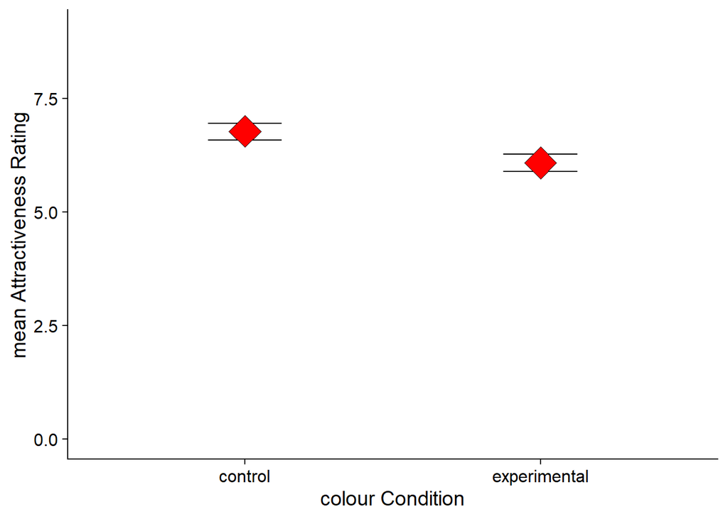

# Method and Design

# Results

# Discussion

From these findings it is important to consider why these results differ from previous studies, what factors could influence these findings and whether red attraction is specific to a woman’s attraction to a man, or whether other influences impact perceptions of attractiveness. This experiment was specific to immediate observations of attractiveness from the participant. A recent study by Williams, Scofield and Whitford (2017) used the colours red and blue specifically attempting to investigate the effects that recent exposure to red create a pairing effect of colour and attractiveness. furthermore, whether the removal of colour when viewing the male or female target changed the participants attraction to the target. The method was participants assigned the the condition either red or blue. Then each participant viewed ten colour-paired faces randomly on a computer with fixation symbols alongside the colour condition. This was used to check attention of participants viewing the pictures on the computer. The participants were then asked to rate the pictures of a man on the attractiveness scale. When pairing red with a female target and later removing the colour red from the picture is was found to reduce the rating of attractiveness. however, when male targets were used the attractiveness level increased. This suggests that women and the pairing of colour red are seen to be more attractive, that when the colour is removed, female targets attractiveness reduced. Linking this to the current experiment results it could be argued that participants already had a preference to the colour red or white. That regardless of the picture of the man, that due to favouring a specific colour, there was a subconscious favouring of the man with the preferential coloured frame. Furthermore, the conditioning of response before completing the experiment may have influenced the participants ratings of attractiveness. when comparing this to the current experiment it shows that prior visualisation of images on backgrounds before rating attractiveness could influence the outcome rather than only viewing a picture of a red or white frame and giving a rating of attractiveness.

When investigating influences of colours on attraction, a woman’s or man’s preferences and heuristic desires are factors that could play a role in perceived attractiveness. Recent studies such as Niesta, Kayster, Elliot and Feltman (2010) showed an influence in colour of clothing when men conversed with potential female partners. That when talking with the female they asked more intimate questions when the woman was wearing red than green. Another factor such as hormonal changes that women go through when ovulating can influence how they change their appearance to look more attractive (Gueguen 2012). Therefore, if a woman’s hormonal changes can influence their own perception of attractiveness of themselves, could this then play a role in their perception of others attractiveness. It could therefore be argued that a person’s own desires and hormonal differences play a part in how one perceives colour and attraction. That not only could exposure to colours influence attractiveness but also desires of attraction. This change in hormonal patterns could therefore influence experiments, that dependent on a woman’s cycle, it could change her perception of attractiveness and preference to colour and attractiveness. it could be argued that with this current study and experiment such influences as age range could impact hormonal influences and therefore the small difference in age predicts that the outcome of means of attraction are likely to be similar due to similar age ranges, that is is a subgroup of the poluation in age range therefore only representable of a specific type not generalisable to the population.

From the findings of this experiment and the variation in participants influence of the colour red and attractiveness certain changes in experimental design could impact the results. One such factor is whether the participant is colour-blind. Due to the nature of the experiment being centred around colour and attraction, eradicating participants who are colour-blind will produce more valid results based on colour.

Based on the findings and comparison of other studies linking colour and attractiveness there are subtle yet influential connections between red and attractiveness. whether other key factors play a role such as conditioning a person’s perception, or hormonal influences, colours create attraction to others. Further studies may deepen the understanding of how colour can evoke a different reaction to attraction, and whether these influences can be manipulated to change a person’s attractiveness with colour. Such ideas as different variations in the colour red could influence attractive ratings, as well as the ages of participants. Furthermore, the conditioning of each participant prior to the experiment could show how manipulation of attractiveness could give different results

Word count 1291

# References

Francis, G. 2013, “Publication bias in “Red, rank, and romance in women viewing men,” by Elliot et al. (2010)", Journal of Experimental Psychology: General, vol. 142, no. 1, pp. 292-296.

Guéguen, N. Makeup and Menstrual Cycle: Near Ovulation, Women Use More Cosmetics. Psychol Rec 62, 541–548 (2012). https://doi-org.ezproxy.sussex.ac.uk/10.1007/BF03395819

Neista Kayser, D., Elliot, A. J., Feltman, R.2010. Red and romantic behavior in men viewing women. European Journal of Social Psychology, 40, 901-908. doi:10.1002/ejsp.757

Schwarz, S. and Singer, M. (2013). Romantic red revisited: Red enhances men’s attraction to young, but not menopausal women. Journal of Experimental Social Psychology 49: 161–164, DOI: https://doi.org/10.1016/j.jesp.2012.08.004

Williams, L. A., Schofield, T. P., & Whitford, T. J. (2017). Romantic Red: Testing the Characteristics of Color–Attraction Effects in a Novel Paradigm. Collabra: Psychology, 3(1), 10. DOI: http://doi.org/10.1525/collabra.54